# Tp_Interprétabilité

Harold Tagny

2024-02-21

### A - Les données

```r
data = gui
head(data)
```

```
##   PM10  NO NO2 SO2 T.min T.max     T.moy DV.maxvv DV.dom VV.max   VV.moy PL.som
## 1   13  42  48   8  -0.6   4.4  1.173913      160  180.0      8 5.347826     11
## 2   13  22  34   7  -1.3   5.6  2.012500       20   22.5      7 4.958333      3
## 3   21  44  55  13  -4.2  -0.7 -2.933333       40  180.0      3 2.250000      0
## 4   29  75  56  16  -2.5   4.0  1.520833      200  202.5      4 2.708333      0
## 5   22 109  67  19   2.4   7.7  5.033333      200  180.0      5 3.250000      0
## 6   18 117  81  18   6.5   9.1  7.629167      210  202.5      6 4.458333      0
##   HR.min HR.max   HR.moy   PA.moy GTrouen GTlehavre
## 1     93     97 96.21739 1010.930     0.7      -0.3
## 2     78     96 87.87500 1016.975    -0.5       0.0
## 3     63     91 82.62500 1024.088     2.4       0.1
## 4     86     97 94.00000 1021.954     2.7      -0.2
## 5     91     98 96.25000 1021.562     2.4      -0.2
## 6     87     97 93.29167 1019.475     0.6      -0.3
```

Nous observons tout d’abord notre base de donnée qui comporte 18 variables ainsi que 1096 observations. Une observation correspond ici à un jour. Concernant les variables ;

Notre base de donnée correspond aux mesures de Air Normandie.

```r
summary(data)
```

```
##       PM10              NO              NO2              SO2
##  Min.   :  6.00   Min.   :  3.00   Min.   : 21.00   Min.   : 0.000
##  1st Qu.: 20.00   1st Qu.: 23.00   1st Qu.: 42.00   1st Qu.: 4.000
##  Median : 25.00   Median : 40.00   Median : 54.00   Median : 6.000
##  Mean   : 26.13   Mean   : 48.78   Mean   : 54.26   Mean   : 7.827
##  3rd Qu.: 31.00   3rd Qu.: 65.00   3rd Qu.: 65.00   3rd Qu.:10.250
##  Max.   :103.00   Max.   :301.00   Max.   :110.00   Max.   :45.000
##  NA's   :7        NA's   :2        NA's   :2        NA's   :12
##      T.min            T.max           T.moy           DV.maxvv
##  Min.   :-8.200   Min.   :-2.00   Min.   :-5.233   Min.   : 10.0
##  1st Qu.: 2.300   1st Qu.: 8.50   1st Qu.: 5.471   1st Qu.:100.0
##  Median : 7.500   Median :14.90   Median :11.279   Median :200.0
##  Mean   : 6.948   Mean   :14.44   Mean   :10.701   Mean   :189.6
##  3rd Qu.:11.600   3rd Qu.:19.90   3rd Qu.:15.629   3rd Qu.:280.0
##  Max.   :19.700   Max.   :34.60   Max.   :26.000   Max.   :360.0
##  NA's   :3        NA's   :3       NA's   :3        NA's   :3
##      DV.dom          VV.max           VV.moy           PL.som
##  Min.   :  0.0   Min.   : 2.000   Min.   : 1.190   Min.   : 0.000
##  1st Qu.: 67.5   1st Qu.: 5.000   1st Qu.: 2.905   1st Qu.: 0.000
##  Median :180.0   Median : 6.000   Median : 3.792   Median : 0.000
##  Mean   :163.7   Mean   : 6.512   Mean   : 4.099   Mean   : 1.722
##  3rd Qu.:270.0   3rd Qu.: 8.000   3rd Qu.: 5.042   3rd Qu.: 1.000
##  Max.   :337.5   Max.   :16.000   Max.   :10.167   Max.   :43.000
##  NA's   :25      NA's   :3        NA's   :3
##      HR.min          HR.max          HR.moy          PA.moy
##  Min.   :19.00   Min.   :71.00   Min.   :44.50   Min.   : 986.8
##  1st Qu.:52.00   1st Qu.:93.00   1st Qu.:75.23   1st Qu.:1012.3
##  Median :64.00   Median :95.00   Median :82.88   Median :1018.1
##  Mean   :64.17   Mean   :94.05   Mean   :81.58   Mean   :1017.6
##  3rd Qu.:76.00   3rd Qu.:97.00   3rd Qu.:88.92   3rd Qu.:1023.4
##  Max.   :99.00   Max.   :99.00   Max.   :99.00   Max.   :1041.0
##  NA's   :3       NA's   :3       NA's   :3       NA's   :3
##     GTrouen         GTlehavre
##  Min.   :-1.500   Min.   :-1.1000
##  1st Qu.: 0.100   1st Qu.:-0.3000
##  Median : 1.200   Median : 0.3000
##  Mean   : 1.649   Mean   : 0.6412
##  3rd Qu.: 2.800   3rd Qu.: 1.3000
##  Max.   :10.300   Max.   : 6.4000
##                   NA's   :9
```

Afin de mieux comprendre les données, nous observons quelques indicateurs descriptifs.

Je remarque qu’il y a quelques variables manquantes dans nos données mais cela reste minime par rapport à ce que nous avons au total. Nous les supprimons afin d’effectuer notre étude car le fait de les remplacer par la moyenne ou bien par la médiane peut nous porter préjudice dans notre étude. Nous ne les prendrons donc pas en compte dans notre étude. Nous avons au total 9 variables numériques décimale ainsi que 9 variables numériques entières.

Afin d’observer si il y a possiblement des saisonnalités notables, j’ai rajouté les jours ainsi que les mois et l’année afin d’effectuer des analyses descriptives par mois dans un premier temps. Ainsi, cela pourrait nous indiquer si un mois ou bien une saison sont plus enclins à concentrer des PM10.

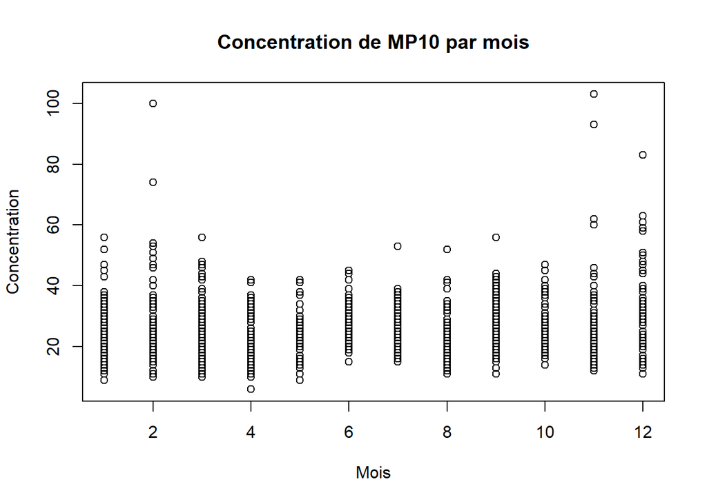

Je remarque que la concentration de PM10 est généralement plus élevée entre Novembre et Février (Hiver). Pendant la période des vacances, elle se trouve alors moins élevée que lors des autres mois. Les valeurs extrêmes restant cependant rares même pendant ces mois, nous ne prendrons pas en considération la saisonnalité dans notre étude.

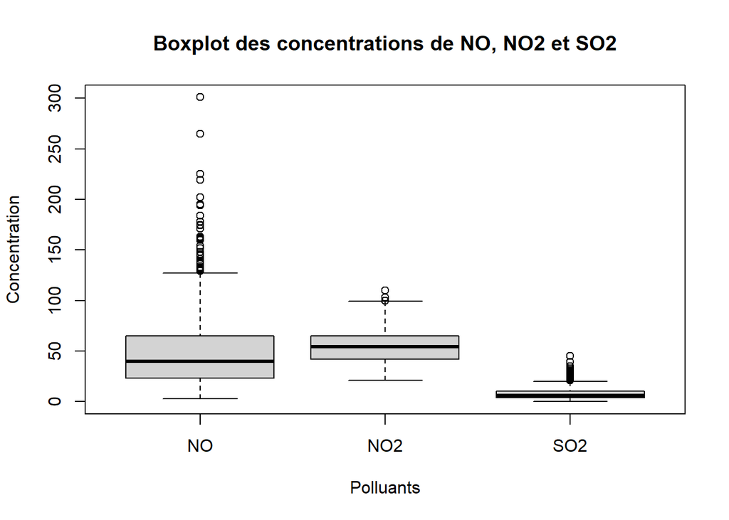

```r
# Créer un boxplot de la concentration de NO, NO2 et SO2
boxplot(data$NO, data$NO2, data$SO2,
        names = c("NO", "NO2", "SO2"),
        xlab = "Polluants",
        ylab = "Concentration",
        main = "Boxplot des concentrations de NO, NO2 et SO2")
```

Grâce à ce boxplot, je remarque que la concentration de SO2 (dioxyde de soufre) est assez regroupée bien que basse. La concentration de NO2 (dioxyde d’azote) est en moyenne supérieure aux concentrations de NO ainsi que de SO2 mais reste moins éparse que celle du NO (monoxyde d’azote).Effectivement la concentration de monoxyde d’azote fluctue principalement entre aucune concentration jusqu’à environ 125 μg/m^3, je remarque cependant que la concentration peut montée jusqu’à 300 μg/m^3 a certains moments.

Afin de se faire une idée de ce que cela représente, nous observons le graphique suivant :

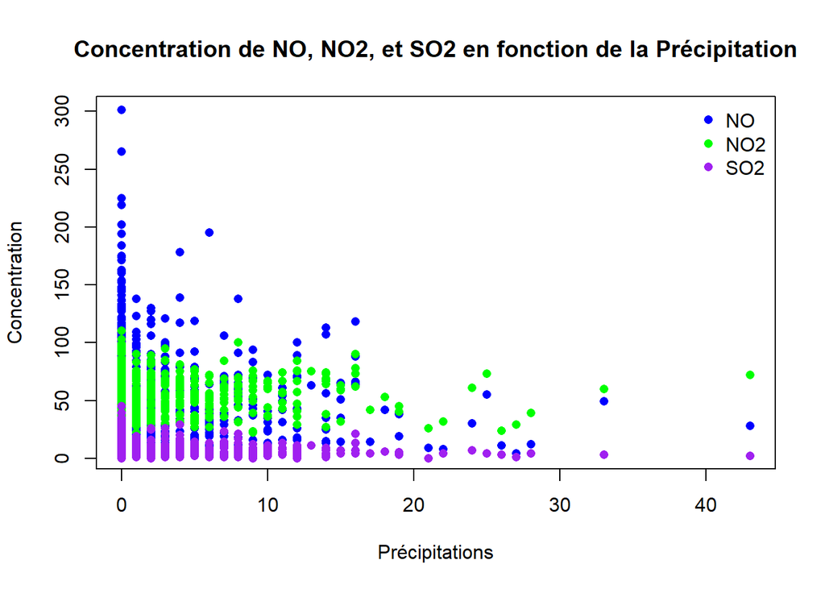

```r
# Tracer les variables NO, NO2 et SO2 en fonction de la précipitation
plot(data$PL.som, data$NO, xlab = "Précipitations", ylab = "Concentration", col = "blue", pch = 16, main = "Concentration de NO, NO2, et SO2 en fonction de la Précipitation")
points(data$PL.som, data$NO2, col = "green", pch = 16)
points(data$PL.som, data$SO2, col = "purple", pch = 16)
legend("topright", legend = c("NO", "NO2", "SO2"), col = c("blue", "green", "purple"), pch = 16, bty = "n")
```

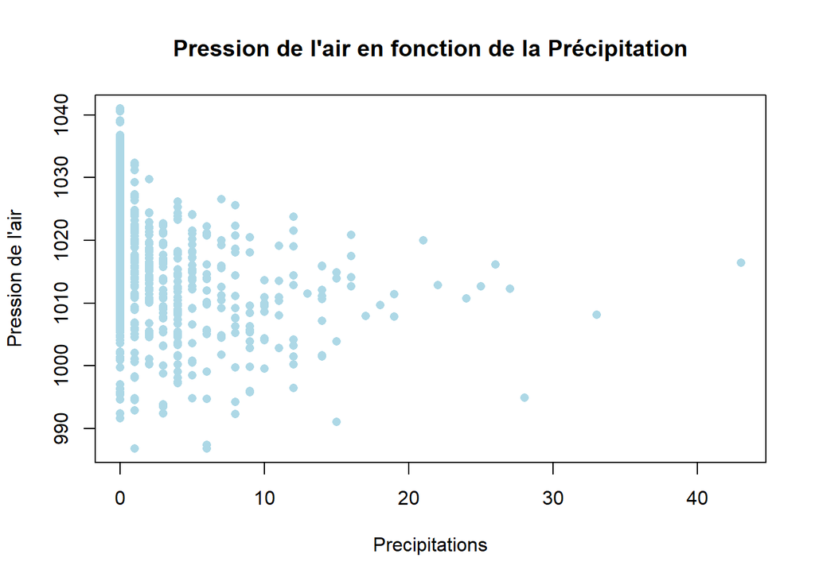

```r
plot(data$PL.som, data$PA.moy, xlab = "Precipitations", ylab = "Pression de l'air", col = "lightblue", pch = 16, main = "Pression de l'air en fonction de la Précipitation")
```

J’effectue un graphique nous retraçant la pression de l’air en fonction de la précipitation et nous remarquons encore une fois que la pression de l’air varie plus que lorsqu’il y a de la pluie. Il y a donc souvent une grande pression de l’air mais lorsque la pluie tombe, la pression de l’air est moins présente.

De cette description rapide, nous remarquons que la pluie peut avoir un impact significatif dans notre étude. Il peut également y avoir une notion de saisonnalité à prendre en compte car la concentration (comme vue plus haut) varie en fonction des mois sur les trois années.

### B - Une fôret aléatoire

Concernant la préparation des données ici, j’ai décidé de ne pas supprimer de données mais de ne pas cependant prendre en compte les données vides afin de ne pas fausser ou bien introduire un biais dans notre forêt aléatoire. Je commence par séparer les données en base d’apprentissage (training - 80%) et en base de test (testing - 20%) après avoir recréer une base de donnée sans les données manquantes afin de pouvoir effectuer convenablement notre étude.

Afin de choisir les bons paramètres de ntree et de mtry, on effectue une validation en observant sur plusieurs paramètres afin de choisir le meilleur.

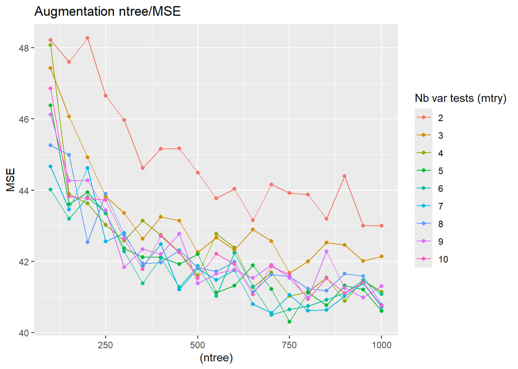

```r
library(randomForest)
library(ggplot2)

 set.seed(23)

# Values to tes for ntree and mtry.

ntree_values <- seq(100, 1000, by = 50)
mtry_values <- seq(2, 10, by = 1)



# stock of the results
results <- data.frame(ntree = numeric(length(ntree_values) * length(mtry_values)),
                      mtry = numeric(length(ntree_values) * length(mtry_values)),
                      MSE = numeric(length(ntree_values) * length(mtry_values)))

# Adjust model to choose the right ntree & mtry
i <- 1
for (ntree in ntree_values) {
  for (mtry in mtry_values) {
    model <- randomForest(PM10 ~ NO + NO2 + SO2 + T.min + T.max + T.moy + DV.maxvv + DV.dom + VV.max + VV.moy + PL.som + HR.min + HR.max + HR.moy + PA.moy + GTrouen + GTlehavre, data = training, ntree = ntree, mtry = mtry)
    results[i, "ntree"] <- ntree
    results[i, "mtry"] <- mtry
    results[i, "MSE"] <- mean(model$mse)
    i <- i + 1
  }
}

# Plot of ntree
ggplot(results, aes(x = ntree, y = MSE)) +
  geom_line(aes(group = mtry, color = factor(mtry))) +
  geom_point(aes(color = factor(mtry))) +
  labs(title = "Augmentation ntree/MSE",
       x = "(ntree)",
       y = "MSE") +
  scale_color_discrete(name = "Nb var tests (mtry)")
```

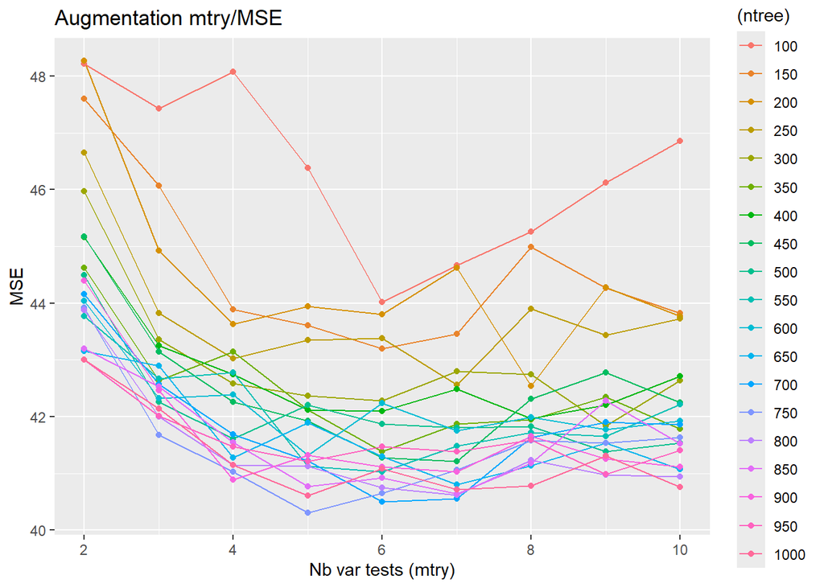

```r
# plot of mtry
ggplot(results, aes(x = mtry, y = MSE)) +
  geom_line(aes(group = ntree, color = factor(ntree))) +
  geom_point(aes(color = factor(ntree))) +
  labs(title = "Augmentation mtry/MSE",
       x = "Nb var tests (mtry)",
       y = "MSE") +
  scale_color_discrete(name = "(ntree)")
```

J’ai tout d’abord pris pour référence les graphiques ci-dessus qui représentent les combinaisons des ntree et des mtry afin d’obtenir l’erreur la plus basse. Cela n’étant qu’une approximation, ça a pu me donner une idée afin de mieux parvenir a choisir mes paramètres.

J’effectue à présent le modèle randomForest avec les variables retenue sur la base d’entrainement.

```r
set.seed(850)
random_forest = randomForest(PM10 ~ NO + NO2 + SO2 + T.min + T.max + T.moy + DV.maxvv + DV.dom + VV.max + VV.moy + PL.som + HR.min + HR.max + HR.moy + PA.moy + GTrouen + GTlehavre,
                            data = training,
                            na.action = na.omit,
                            ntree = 360,
                            importance = T,
                            mtry = sqrt(ncol(training)))
print(random_forest)
```

```
##
## Call:
##  randomForest(formula = PM10 ~ NO + NO2 + SO2 + T.min + T.max +      T.moy + DV.maxvv + DV.dom + VV.max + VV.moy + PL.som + HR.min +      HR.max + HR.moy + PA.moy + GTrouen + GTlehavre, data = training,      ntree = 360, importance = T, mtry = sqrt(ncol(training)),      na.action = na.omit)
##                Type of random forest: regression
##                      Number of trees: 360
## No. of variables tried at each split: 5
##
##           Mean of squared residuals: 39.96055
##                     % Var explained: 57.19
```

J’ai effectué le modèle en ajoutant la fonction na.omit afin de ne pas prendre en compte dans les fôrets les valeurs manquantes. Avec ce modèle, je parviens à expliquer 57.19% de la variance ainsi qu’une erreur résiduelle de 39.96. La fonction na.action = na.omit permet de ne sélectionner que les valeurs qui ne sont pas vides.